# Day_5 slides

## Introduction to Python with Application in Bioinformatics

### Nanjiang Shu

#### 2024-07-19 (Day 5)

### Review of Day 4

- Scop of variables
  - Local variables vs global variables and at which scope they are accessible
  - Be cautious when using global variables.
- Positional arguments and keyword arguments
  - Positional arguments and keyword arguments are passed differently to the functions
  - Use keyword arguments to improve the clarity.
- `return` statement
  - Functions return a meaningful value are easier to repurpose and more usable.
- Comments and documentation
  - How to create your own module with both module level documentation and help message for functions
  - Although code should explain by itself, comment the code when it's hard to understand.
- Importing modules: using libraries
  - import os
  - from math import pi
- Brief introduction to Biopython using `SeqIO`

### Review of the quiz from Day 4

- [Link to the quiz statistics](https://forms.office.com/Pages/DesignPageV2.aspx?origin=NeoPortalPage&subpage=design&id=DQSIkWdsW0yxEjajBLZtrQAAAAAAAAAAAAa__Yehr4dUQkVYOVlONlNIVEVZRTEyUTAwT0s0SzgzTy4u&analysis=true)

### Question 2:

If a local variable shares the same name as a global variable, which will be used within the function?

```
   A: The function will use the global variable
✔  B: The function will use the local variable
   C: Python will throw an error
   D: It will choose randomly
```

```python
def show_host():
    host = 'local'
    print(f'host inside the function = {host}')

host = 'global'
show_host()
```

```
host inside the function = local
```

## Day 5

- Session 1:
  - Pandas for data manipulation and basic plotting
- Session 2:
  - An introduction to AI assisted programming
- Sum up

Project time after lunch

## Pandas

- Library for working with tabular data, e.g. csv, tsv and excel
- Data analysis:
  - filtering
  - transformation, that is, element wise data mapping
  - aggregation, that is, combining or summerizing data
  - plotting

### In Padas, data is stored as a `DataFrame`

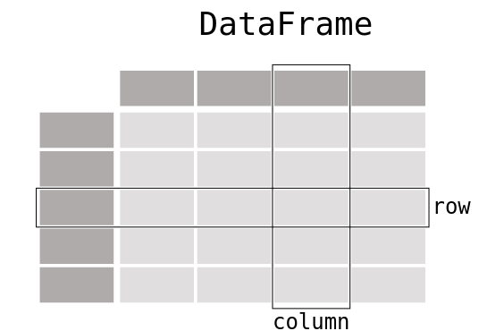

### Creating a DataFrame

```python
import pandas as pd
mydict = {
    'age': [1,2,3,4],
    'circumference': [2,3,5,10],
    'height': [30, 35, 40, 50]
}
df = pd.DataFrame(mydict)
df
```

|  | age | circumference | height |
| --- | --- | --- | --- |
| 0 | 1 | 2 | 30 |
| 1 | 2 | 3 | 35 |
| 2 | 3 | 5 | 40 |
| 3 | 4 | 10 | 50 |

- One column of implict row index (0, 1, 2, 3) is added
- Keys are treated as column names: `age`, `circumference`, `height`

```python
# To set 'age', ''circumference' and 'height' as rows, you need to transpose the matrix
df.T
```

|  | 0 | 1 | 2 | 3 |
| --- | --- | --- | --- | --- |
| age | 1 | 2 | 3 | 4 |
| circumference | 2 | 3 | 5 | 10 |
| height | 30 | 35 | 40 | 50 |

### Reset the index names

```python
df = pd.DataFrame(mydict)
print(df)
df = pd.DataFrame(mydict, index=["row1", "row2", "row3", "row4"])
df
```

```
   age  circumference  height
0    1              2      30
1    2              3      35
2    3              5      40
3    4             10      50
```

|  | age | circumference | height |
| --- | --- | --- | --- |
| row1 | 1 | 2 | 30 |
| row2 | 2 | 3 | 35 |
| row3 | 3 | 5 | 40 |
| row4 | 4 | 10 | 50 |

### Reset the index names after creation

```python
df = pd.DataFrame(mydict)
print(df)
df = df.rename(index={0:"row1"})
df
```

```
   age  circumference  height
0    1              2      30
1    2              3      35
2    3              5      40
3    4             10      50
```

|  | age | circumference | height |
| --- | --- | --- | --- |
| row1 | 1 | 2 | 30 |
| 1 | 2 | 3 | 35 |
| 2 | 3 | 5 | 40 |
| 3 | 4 | 10 | 50 |

### Reset the column names

```python
df = pd.DataFrame(mydict)
print(df)
df = df.rename(columns={"age": "newAge"})
df
```

```
   age  circumference  height
0    1              2      30
1    2              3      35
2    3              5      40
3    4             10      50
```

|  | newAge | circumference | height |
| --- | --- | --- | --- |
| 0 | 1 | 2 | 30 |
| 1 | 2 | 3 | 35 |
| 2 | 3 | 5 | 40 |
| 3 | 4 | 10 | 50 |

```python
df.columns = ["1", "2", "3"]
df
```

[output not shown]

### You can not reset column names duration its creation

```python
# However, you can not reset column names duration it's creation
df = pd.DataFrame(mydict, columns=["newAge", "NewC", "NewH"])
df
```

|  | newAge | NewC | NewH |
| --- | --- | --- | --- |

#### This is because when you define the DataFrame the keys in the dictionary must match the column names exactly when passed to `pd.DataFrame()`

### The data of columns must have the same length

```python
mydict = {
    'age': [1,2,3,4],
    'circumference': [2,3,5,10],
    'height': [30, 35, 40, 50]
}
df = pd.DataFrame(mydict)
df
```

|  | age | circumference | height |
| --- | --- | --- | --- |
| 0 | 1 | 2 | 30 |
| 1 | 2 | 3 | 35 |
| 2 | 3 | 5 | 40 |
| 3 | 4 | 10 | 50 |

### Overview of your data, basic statistics

```python
df
```

|  | age | circumference | height |
| --- | --- | --- | --- |
| 0 | 1 | 2 | 30 |
| 1 | 2 | 3 | 35 |
| 2 | 3 | 5 | 40 |
| 3 | 4 | 10 | 50 |

```python
df.shape
```

```
(4, 3)
```

```python
df.describe()
```

|  | age | circumference | height |
| --- | --- | --- | --- |
| count | 4.000000 | 4.000000 | 4.000000 |
| mean | 2.500000 | 5.000000 | 38.750000 |
| std | 1.290994 | 3.559026 | 8.539126 |
| min | 1.000000 | 2.000000 | 30.000000 |
| 25% | 1.750000 | 2.750000 | 33.750000 |
| 50% | 2.500000 | 4.000000 | 37.500000 |
| 75% | 3.250000 | 6.250000 | 42.500000 |
| max | 4.000000 | 10.000000 | 50.000000 |

```python
df.max()
```

```
age               4
circumference    10
height           50
dtype: int64
```

```python
df.std()
```

[output not shown]

### Numerical options will be applied on every element

```python
print(df)
(df+2)*2-1
```

```
   age  circumference  height
0    1              2      30
1    2              3      35
2    3              5      40
3    4             10      50
```

|  | age | circumference | height |
| --- | --- | --- | --- |
| 0 | 5 | 7 | 63 |
| 1 | 7 | 9 | 73 |
| 2 | 9 | 13 | 83 |
| 3 | 11 | 23 | 103 |

## How to select data from a DataFrame

### Selecting columns from a dataframe

```
dataframe.columnname
dataframe['columnname']
```

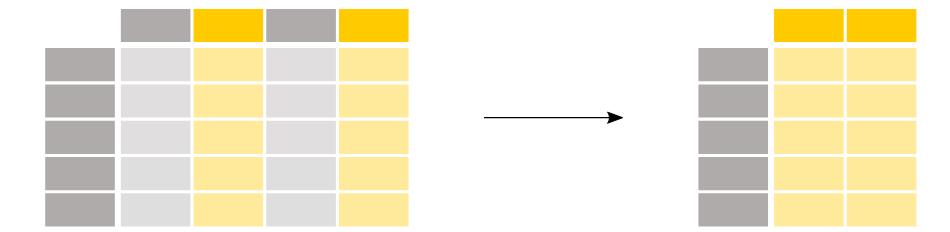

[output not shown]

```python
df.0 # does not work if the column name is an integer
```

```python
# create a new dataframe from the selected dataframe and do further operations
df_new = df.height
```

### Selecting multiple columns

```python
df[['age', 'height']]
```

|  | age | height |
| --- | --- | --- |
| 0 | 1 | 30 |
| 1 | 2 | 35 |
| 2 | 3 | 40 |
| 3 | 4 | 50 |

```python
df[['height', 'age']] # what's the difference?
```

|  | height | age |
| --- | --- | --- |
| 0 | 30 | 1 |
| 1 | 35 | 2 |
| 2 | 40 | 3 |
| 3 | 50 | 4 |

### Selecting rows from a dataframe

- **Using integer index**

  ```
  dataframe.iloc[index]
  dataframe.iloc[start:stop]
  ```

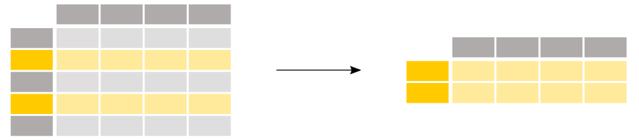

```python
df.iloc[0] # select the first row
```

```
age               1
circumference     2
height           30
Name: 0, dtype: int64
```

```python
df.iloc[1:3] # select from row 2 to 3
```

|  | age | circumference | height |
| --- | --- | --- | --- |
| 1 | 2 | 3 | 35 |
| 2 | 3 | 5 | 40 |

### Selecting rows from a dataframe

- **Using label index**

  ```
  dataframe.loc[row_label]
  dataframe.loc[start_label:end_label] (both ends are inclusive)
  ```

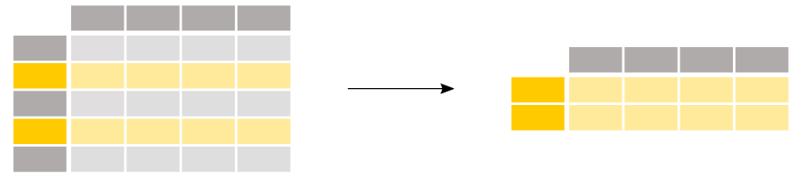

```python
df = df.rename(index={0:"row1", 1:"row2", 2:"row3", 3:"row4"})
print(df)
df.loc['row1'] # select from row 1
```

```
      age  circumference  height
row1    1              2      30
row2    2              3      35
row3    3              5      40
row4    4             10      50
```

```
age               1
circumference     2
height           30
Name: row1, dtype: int64
```

```python
df.loc['row1':'row3'] # select from row 1 to 3
```

|  | age | circumference | height |
| --- | --- | --- | --- |
| row1 | 1 | 2 | 30 |
| row2 | 2 | 3 | 35 |
| row3 | 3 | 5 | 40 |

```python
df.loc[['row1', 'row3']] # select row 1 and row 3
```

|  | age | circumference | height |
| --- | --- | --- | --- |
| row1 | 1 | 2 | 30 |
| row3 | 3 | 5 | 40 |

```python
df.loc[['row3', 'row2']] # select row 2 and row3, order changed
```

|  | age | circumference | height |
| --- | --- | --- | --- |
| row3 | 3 | 5 | 40 |
| row2 | 2 | 3 | 35 |

### Selecting top and bottom rows by `.head` and `.tail`

```python
df.head(2)
```

|  | age | circumference | height |
| --- | --- | --- | --- |
| row1 | 1 | 2 | 30 |
| row2 | 2 | 3 | 35 |

```python
df.tail(2)
```

|  | age | circumference | height |
| --- | --- | --- | --- |
| row3 | 3 | 5 | 40 |
| row4 | 4 | 10 | 50 |

### Selecting rows by condition

```python
df[df['height'] >= 40]
```

|  | age | circumference | height |
| --- | --- | --- | --- |
| row3 | 3 | 5 | 40 |
| row4 | 4 | 10 | 50 |

```python
df[(df['height'] == 40) & (df['circumference'] <= 10)]
```

|  | age | circumference | height |
| --- | --- | --- | --- |
| row3 | 3 | 5 | 40 |